# R for Statistical Programming

Programmer, Göteborg, Sweden

## Overview

Introducing R for Statistical Programming

- Basics of R
- Accessing and Generating Data
- Modifying Data
- Producing Outputs

## Learning R

## Why learn R?

R is a programming language used for statistical programming

Useful for:

- **Data manipulation** (e.g. merging datasets, correcting inconsistencies)

```
##     Country Dial_Code
## 1    Sweden        46
## 2   Finland       358
## 3 Australia        61
## 4        UK        44
```

```
##          Country Population_M
## 1         Sweden        10.23
## 2         Norway         5.33
## 3 United Kingdom        66.65
```

```
##          Country Dial_Code Population_M
## 1      Australia        61           NA
## 2        Finland       358           NA
## 3         Norway        NA         5.33
## 4         Sweden        46        10.23
## 5 United Kingdom        44        66.65
```

## Why learn R?

R is a programming language used for statistical programming

Useful for:

- **Data manipulation** (e.g. merging datasets, correcting inconsistencies)
- **Statistical analysis** (e.g. *t*-tests, regression, ANOVA)

```
##
##  Welch Two Sample t-test
##
## data:  iris$Sepal.Length[iris$Species == "setosa"] and iris$Sepal.Length[iris$Species == "virginica"]
## t = -15.386, df = 76.516, p-value < 2.2e-16
## alternative hypothesis: true difference in means is not equal to 0
## 95 percent confidence interval:
##  -1.78676 -1.37724
## sample estimates:
## mean of x mean of y
##     5.006     6.588
```

## Why learn R?

R is a programming language used for statistical programming

Useful for:

- **Data manipulation** (e.g. merging datasets, correcting inconsistencies)
- **Statistical analysis** (e.g. *t*-tests, regression, ANOVA)
- **Producing outputs** (e.g. scatterplots, boxplots, histograms, tables)

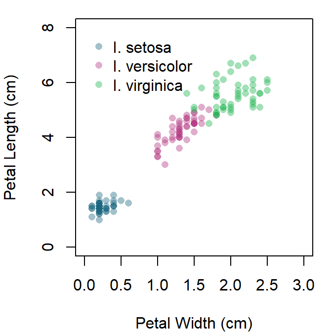

## How to use R

R is a programming language, we use it by writing programs

- Programs perform specific intended tasks
- Programs are a **script** of code
- Programs produce the required result when **executed** in a **console**

The R program provides a console

- Open R and execute

```r
1+2+3
```

```
## [1] 6
```

Is this a sensible way to use R?

- We don’t really write and execute R code line-by-line into the console

## How to *really* use R

Most R users will use a **G**raphical **U**ser **I**nterface (GUI), a good GUI will

- Provide a text editor
- Provide a console (or connection to the R console)
- Allow extensive scripts to be built, edited and saved
- Make it easy to execute code
- Give color-coded syntax in the editor (and console)

Among the most popular are:

- RStudio
- Jupyter
- Notepad++
- R (we can open a script in R)

My preference is RStudio

- Keyboard shortcuts in this class are specific to RStudio.

## How to use RStudio

Task: create a new program in RStudio

- *File* \(\rightarrow\) *New File* \(\rightarrow\) *R Script*

Add code to the program

- Write `1+2+3` in the editor pane

Execute the code

- *Ctrl* + *Enter* executes current line/selected code and moves cursor to next line
- *Alt* + *Enter* executes current line/selected code, cursor stays put
- *Ctrl* + *Alt* + *R* executes the entire program
- *Ctrl* + *Alt* + *B* executes the program from beginning to cursor position
- *Ctrl* + *Alt* + *E* executes the program from cursor position to the end

The output is in the console pane

*Tip: more keyboard shortcuts can be shown by pressing Alt + Shift + K!*

## Customising RStudio

Appearance can be heavily customised to suit preferences

- Layout of panes (editor, console, plots etc.)
- Color scheme

Go to *Tools* \(\rightarrow\) *Global Options* to explore settings

- Try different color schemes and layouts to suit your preferences
- Remember that color schemes affect syntax highlighting and eye strain

Lots of other behaviour can be modified including

- Auto-completion of braces, quotes etc.
- Customisation of keyboard shortcuts
- Spell checker language

## Getting help with R (TODO)

stackoverflow

- tags R != RStudio
- provide reproducible examples
- do good research
- show initiative

R sig mailing lists

Vignettes

## Basic Programs in R

## Hello, world!

The classic first program when learning any language

```r
print("Hello, world!")
```

Q: what will be the output?

```
## [1] "Hello, world!"
```

Uses the `print()` **function** to return the data `"Hello, world!"` - a text string - in the console.

## Coin-toss simulation

Simulate tossing a coin 10 times and show the score

```r
sample(c("Heads", "Tails"), size = 10, replace = TRUE)
```

Q: what will be the output?

```
##  [1] "Heads" "Tails" "Heads" "Heads" "Tails" "Heads" "Heads" "Heads" "Tails"
## [10] "Tails"
```

Uses the `sample()` **function** to sample 10 values of *heads* and *tails*.

## Create a coin-toss simulation function

Puts the previous simulation into a function, allowing *n* to be specified as an **argument** in the function and giving a frequency table of the results using the `table()` function.

```r
coin_toss <- function(n){
  table(sample(c("Heads", "Tails"), size = n, replace = TRUE))
}
coin_toss(n = 10)
coin_toss(n = 1000)
```

Q: what will be the output?

```
##
## Heads Tails
##     6     4
##
## Heads Tails
##   498   502
```

Wraps the previous code into a function using the `function()` function. When executed, `coin_toss()` executes the underlying R code for the given value of `n` in the function call

*Tip: functions are referred to with parentheses making it more obvious that they are a function*

## Basic programs

These basic programs showed the key components of programs

- Functions
- Data

Functions and data are both **objects** in R

Data objects and user-made functions are stored in the **workspace** or **working environment**, a temporary storage location that empties when the session ends, when **assigned** to a variable

- Calling the object by name returns it’s contents, e.g.

```r
x <- c(1, 2, 3)
x
```

```
## [1] 1 2 3
```

Built-in data and functions also exist in **packages** which can be connected to the session

- Some are present on session start-up (e.g. `stats`, `base`, `datasets`)

## Assignment

Objects are created by **assigning** a name to an object using an **assignment operator**

- Typically we use `<-` and `=`
- For these the name is on the left-hand side, value on the right

Task: create an object called `my_name` with your name as the value and print the value to the console by using the stored data object as an argument

```r
my_name <- "Rob"
print(my_name)
```

```
## [1] "Rob"
```

## Functions

One of the key components of a program, **functions perform processes**

- They are responsible for what happens in a program
- Perform processes such as calculate mean or variance, read/write data files, create plots, perform statistical tests

Programs normally feature multiple functions

A program might aim to give summary statistics (mean, standard error and median) for a variable, split by groups

- Functions to load data
- Functions to modify data
- Functions to get mean, standard error and median
- Functions to create a table
- Functions to write that table to storage

## Data

The other key component of a program is data

- Normally loaded or **read** from a directory
- Can be loaded from multiple file types
- Can also be built-in datasets, data read from URLs, data pasted into R or data generated within R

Data is simply the values being processed and generated in an R program

## Functions and data

Functions act on data

In the *hello, world!* program

- `print()` was the function
- `"Hello, world!"` was the data
- The `print()` function returned the value of the data to the console
- We could assign the value `"Hello, world!"` to a variable, `x` and use `x` as the argument in `print()`

```r
x <- "Hello, world!"
print(x)
```

```
## [1] "Hello, world!"
```

Q: what other functions did we encounter in the basic programs?

- `sample()`
- `table()`
- `function()`
- `c()`

## Comments

Comments are a third key component of a program

- Not critical to the program; not executed
- **Critical to the programmer**
- Occur on the right-hand side of `#` in R

```r
# This is a comment
print("Hello, world!") # This is also a comment
```

```
## [1] "Hello, world!"
```

Comments make it easier to collaborate on and return to programs, keep workflow tidy, and document changes and decision making

- There is a myth that comments are a bad, a sign of weakness because code should be self-explanatory
- Use liberally, not to say what is being done, but to clarify how and why

Q: Good or bad comment? Why?

```r
# Subtract 32 from values then multiply by five-ninths
(c(99.2, 98.3, 99.1) - 32) * 5/9
```

```
## [1] 37.33333 36.83333 37.27778
```

## Comments

Comments are a third key component of a program

- Not critical to the program; not executed
- **Critical to the programmer**
- Occur on the right-hand side of `#` in R

```r
# This is a comment
print("Hello, world!") # This is also a comment
```

```
## [1] "Hello, world!"
```

Comments make it easier to collaborate on and return to programs, keep workflow tidy, and document changes and decision making

- There is a myth that comments are a bad, a sign of weakness because code should be self-explanatory
- Use liberally, not to say what is being done, but to clarify how and why

Q: Good or bad comment? Why?

```r
# Temperature recorded in farenheit, convert to celsius (see protocol SAP332.4)
(c(99.2, 98.3, 99.1) - 32) * 5/9
```

```
## [1] 37.33333 36.83333 37.27778
```

## Basic programs: summary

Programs are written to perform a set of tasks

Take data and apply functions

Well written programs are clear, concise, efficient and well annotated

## How R understands data

## Data in R

Previous section introduced data and functions

Data is critical to statistical programming, it contains the information we are trying to unlock

To R, data is simply one or more values

- Each value is an **element**
- Elements of data have set **data types**
- Elements are stored into structures of a specific **data class**

This section covers data type and class

Type and class affect the behaviour of R. Understanding them will help prevent and diagnose errors in programming

## Data type

Six data types in R, four are encountered by programmers on a regular basis

- Logical
- Integer
- Double
- Character

The vast majority of data handled is one of these four

Data type can be returned using the `typeof()` function

```r
typeof(12)
```

```
## [1] "double"
```

## Creating programs

## Introduction (TODO)

Now seen the contents and structure of programs and how R understand data

We can finally move on to actually building programs

## Base R, tidyverse and data.table (TODO)

Three major sets of tools

data.table is an extension of the data.frame, adding better syntax, computational efficiency and greater functionality

## Accessing and Generating Data: PLAN

- Datasets
  - Built in datasets
  - Reading datafiles
    - Structured and unstructured datasets
  - From URLs
  - Pasted text
  - Generating Data
    - using sample(), rnorm() etc.
    - dput()

## Modifying Data: PLAN

- Ordering data
- Filtering observations
  - Logical operators
- Selecting variables
- Generating and processing-on variables
- Handling strings
- Handling dates

## Examples

Here is some `code in text` to test

```r
# Highlighted code
mean(c(1:5))
x <- 10
y <- x * 2
y
x + y
```

```
## [1] 3
## [1] 20
## [1] 30
```